# RocketOutfall

PREVENT DAYLIGHTING  
Finding water management solutions for continual groundwater treatment

## Project Background

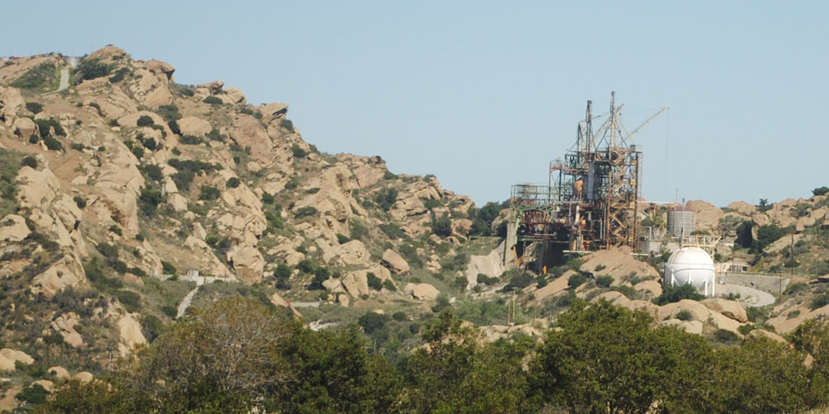

The Santa Susana Field Laboratory was a rocket engine development and testing site for nearly 60 years. Industrial chemicals used during testing contaminated the groundwater and settled into the fractures and pores of the sandstone bedrock. The Boeing Company, as the current owner of the property, is overseeing the transition of the site to a wildlife conservation area. They will continue to manage the groundwater and contaminant plumes at the 2,850 acre site for the foreseeable future.

## Problem

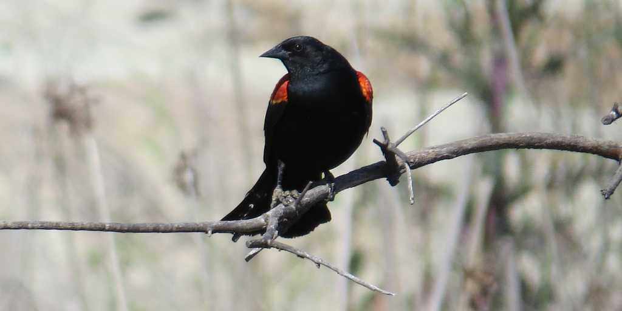

Heavy rains could cause the underground contaminated water to rise enough to flow on the surface, known as **daylighting.** To prevent this, Boeing has to pump groundwater to keep water levels below surface springs. There is currently no long-term strategy to manage the pumped water, which is treated to remove contaminants. As a result, groundwater pumping has been sporadic.  
The two issues:

1. If groundwater is not pumped, daylighting could occur.
2. If the discharge of pumped water is improperly managed, existing habitats could be adversely impacted.

## Finding Solutions

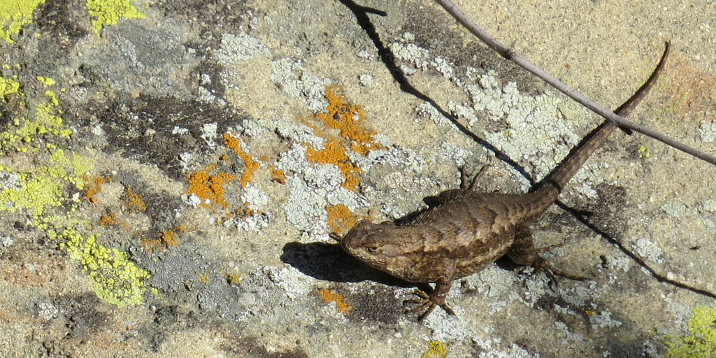

By evaluating options for the influx of pumped water, we aim to find suitable water **outfall** strategies that would allow the groundwater to be treated continuously at the Santa Susana Field Laboratory.

In addition, we will investigate creative uses for the water — The projected amount of water could even support water-deprived ecosystems.

## Objectives

1. Evaluate how channel flow from the discharge of treated groundwater might influence soil moisture and vegetation communities by transforming ephemeral channels into perennial streambeds.
2. Investigate useful alternatives to the proposed surface discharge.

## Client: Boeing

Boeing is currently running the remedation activites at the Santa Susana site.

[Learn More About Boeing’s Remediation of SSFL](http://www.boeing.com/principles/environment/santa-susana/index.page)

## More Information

This is a capstone group project for the Bren School of Environmental Science and Management at the University of California Santa Barbara.

[figure not shown]